# BOSCC Generalizability

Rebecca Grzadzinski

# BACKGROUND

The Brief Observation of Social Communication Change (BOSCC) is a coding scheme of ASD symptoms that is used as a treatment response measure. The BOSCC coding scheme has been validated in a study of toddlers who participated in early interventions (n=56) over the course of about 6 months (Grzadzinski et al., 2016). In this work, the coding scheme was applied to 10-minute videos of parent-child free-play sessions (Standard BOSCC). Subsequent work aimed to validate the coding scheme when applied to segments of video-tapes ADOS administrations (a standardized interaction with a clinician; ADOS-BOSCC; Kim, Martinez, Grzadzinski, & Lord, 2019). This work confirmed the utility of the BOSCC as a treatment outcome measure when applied to parent-child and clinician-child interactions. Even though both of these projects used an overlapping sample of children participating in early intervention trials, we do not know whether the children who show change over time on the Standard BOSCC are the same as those that show change on the ADOS-BOSCC. In addition, we do not know if there are baseline child characteristics that predict whether more change will be observed on the Standard BOSCC vs. ADOS-BOSCC.

# OBJECTIVES:

1. To evaluate whether children who show improvements on the Standard BOSCC are the same as the children who show improvements on the ADOS-BOSCC.
2. To determine whether there are baseline child characteristics (e.g., NVIQ, VIQ, Age) that predict more improvement on the Standard BOSCC vs. the ADOS-BOSCC.

## INFORMATION ON THIS DATASET

10 toddlers seen at 2 time points. 32 toddlers seen at 3 time points. 5 toddlers seen at 4 time points. 2 toddlers seen at 5 time points.

(39 toddlers with 3+ time points of data).

## Data Cleaning

```r
knitr::opts_chunk$set(echo = FALSE, message = FALSE, warning = FALSE)

library(tidyverse)
library(gridExtra)
library(ggpubr)
library(nlme)
library(lcmm)
library(naniar)
library(kableExtra)
library(broom)
library(pander)

Full_Long<- read_csv("Data/Original_Full_Long_forR.csv") %>%
  mutate(MELTSC=ifelse(MELTSC==666, NA, MELTSC),
         MRLTSC=ifelse(MRLTSC==666, NA, MRLTSC))
FL_Long<- read_csv("Data/FL_Long_forR.csv")
FL_Wide<- read_csv("Data/FL_Wide_forR2.csv")
Full_Long_SAS <- data.frame(lapply(Full_Long, function(x){ifelse(is.na(x)==1|x=="N/A","",x)}))
write.csv(x=Full_Long_SAS, file="Data/Full_Long_SAS.csv")
```

## OBJECTIVE 1:

Correlations at single time points *n=49 kids seen for 146 observations; full long dataset*

*Take-Away: At any single time point, there is a significant correlation between Standard BOSCC and ADOS BOSCC SC and RRB scores*

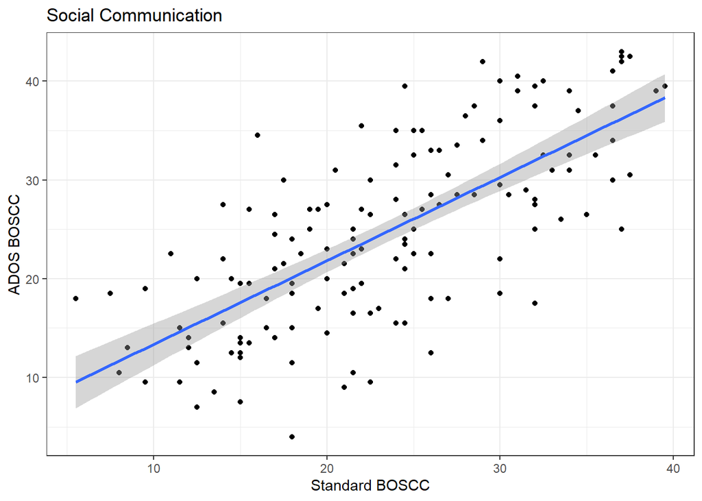

```
##
##  Pearson's product-moment correlation
##
## data:  Full_Long$Code2SCAvgTot and Full_Long$AB_Code2SCAvgTot
## t = 12.403, df = 144, p-value < 2.2e-16
## alternative hypothesis: true correlation is not equal to 0
## 95 percent confidence interval:
##  0.6297770 0.7890266
## sample estimates:
##       cor
## 0.7186981
```

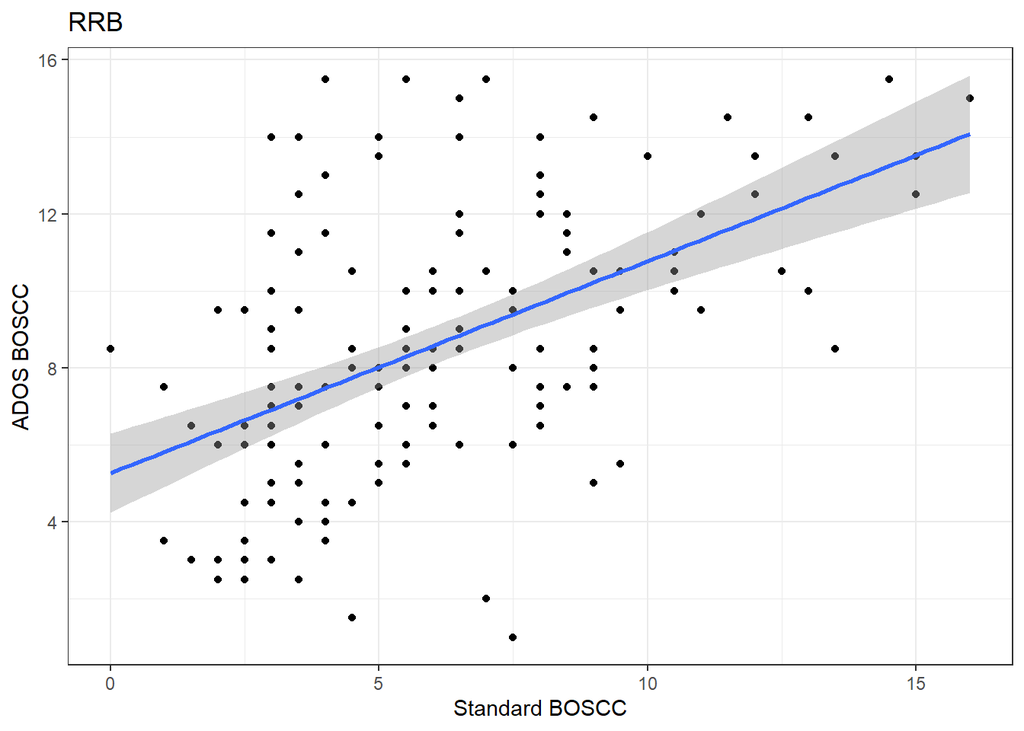

```
##
##  Pearson's product-moment correlation
##
## data:  Full_Long$Code2RRBAvgTot and Full_Long$AB_Code2RRBAvgTot
## t = 7.4175, df = 144, p-value = 9.448e-12
## alternative hypothesis: true correlation is not equal to 0
## 95 percent confidence interval:
##  0.3972713 0.6340772
## sample estimates:
##       cor
## 0.5257874
```

Creating change variables

```
##  ABOSCC_SC_Change  BOSCC_SC_Change   BOSCC_RRB_Change   ABOSCC_RRB_Change
##  Min.   :-23.000   Min.   :-22.000   Min.   :-10.5000   Min.   :-10.5000
##  1st Qu.:-11.500   1st Qu.: -9.500   1st Qu.: -3.5000   1st Qu.: -2.5000
##  Median : -5.000   Median : -4.000   Median : -1.5000   Median : -0.5000
##  Mean   : -4.796   Mean   : -4.612   Mean   : -0.9184   Mean   : -0.5816
##  3rd Qu.:  0.500   3rd Qu.:  0.000   3rd Qu.:  1.5000   3rd Qu.:  2.0000
##  Max.   : 25.000   Max.   : 17.500   Max.   :  7.0000   Max.   :  8.0000
##
##  BOSCC_Core_Change ABOSCC_Core_Change BOSCC_Overall_Change
##  Min.   :-27.500   Min.   :-32.000    Min.   :-30.000
##  1st Qu.:-14.000   1st Qu.:-13.000    1st Qu.:-15.000
##  Median : -7.000   Median : -5.000    Median : -7.000
##  Mean   : -6.061   Mean   : -5.378    Mean   : -7.042
##  3rd Qu.:  1.000   3rd Qu.:  0.500    3rd Qu.:  0.125
##  Max.   : 23.000   Max.   : 33.000    Max.   : 19.000
##                                       NA's   :1
##  ABOSCC_Overall_Change
##  Min.   :-32.000
##  1st Qu.:-15.000
##  Median : -4.000
##  Mean   : -5.847
##  3rd Qu.:  1.000
##  Max.   : 35.000
##
```

## Scatter plots of change from first to last

*Take-Away: From first to last observation, there is a significant correlation between Standard BOSCC Change and ADOS BOSCC Change for both SC and RRB.*

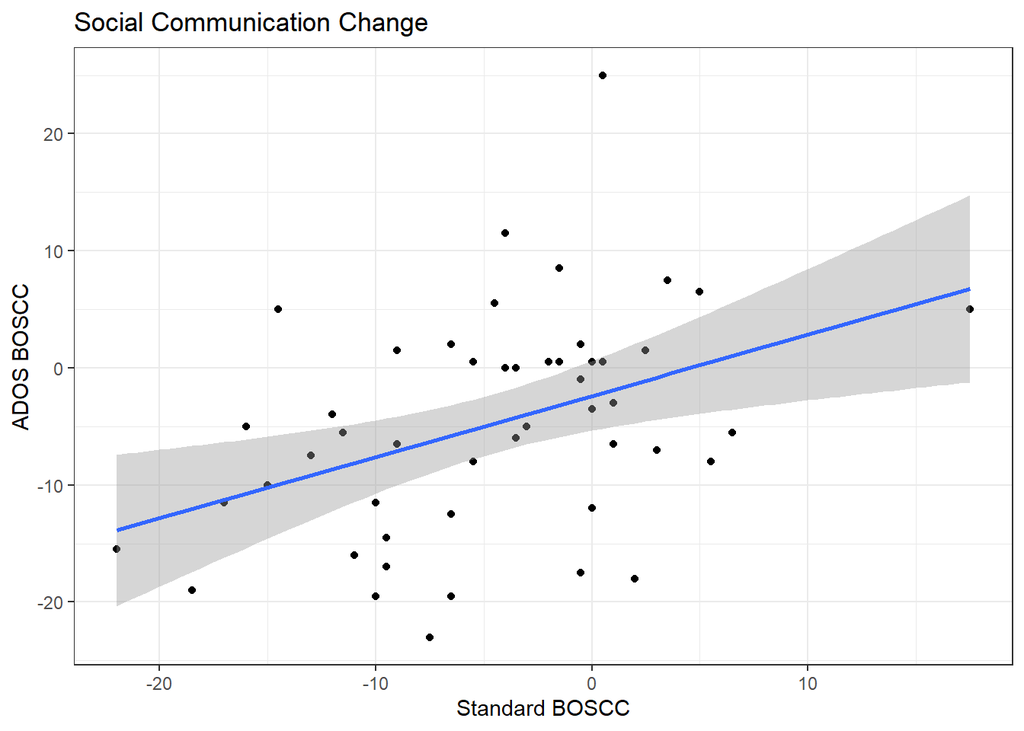

```
##
##  Pearson's product-moment correlation
##
## data:  FL_Wide$BOSCC_SC_Change and FL_Wide$ABOSCC_SC_Change
## t = 3.0682, df = 47, p-value = 0.003569
## alternative hypothesis: true correlation is not equal to 0
## 95 percent confidence interval:
##  0.1438222 0.6186334
## sample estimates:
##       cor
## 0.4084982
```

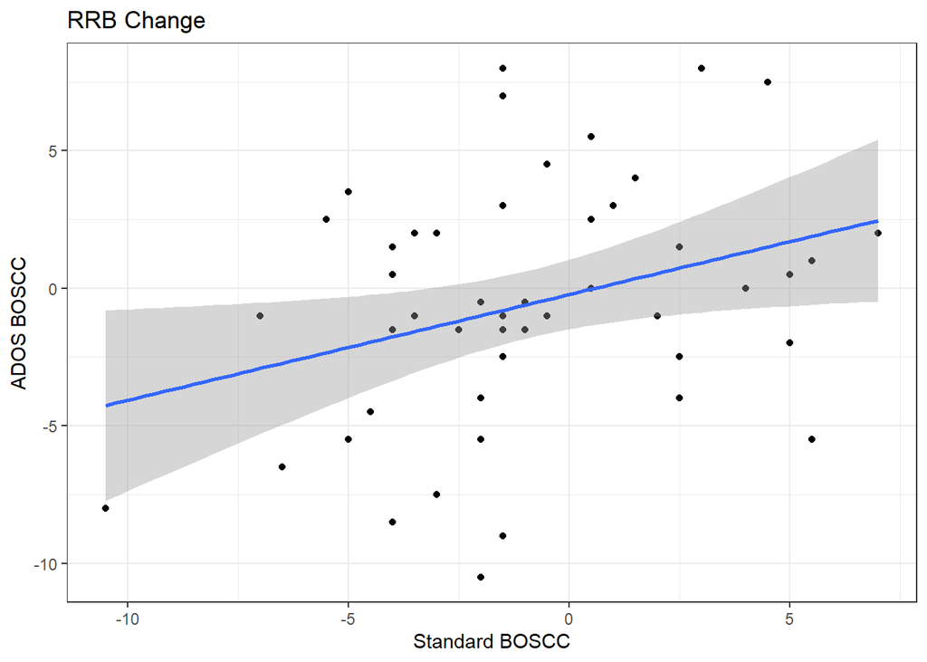

```
##
##  Pearson's product-moment correlation
##
## data:  FL_Wide$BOSCC_RRB_Change and FL_Wide$ABOSCC_RRB_Change
## t = 2.2875, df = 47, p-value = 0.02671
## alternative hypothesis: true correlation is not equal to 0
## 95 percent confidence interval:
##  0.03876991 0.54886198
## sample estimates:
##       cor
## 0.3165158
```

## Plots of BOSCC score by time

Looking at kids with 3 time points only.

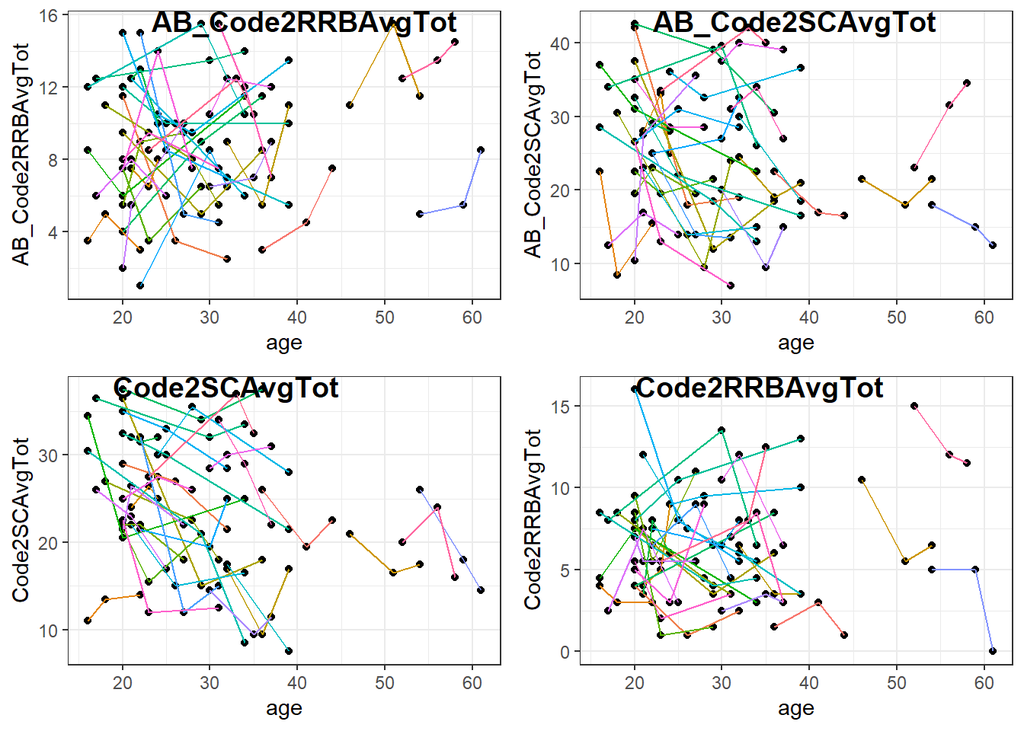

# Modeling

Now consider modeling these trends between BOSCC and BOSCC-ADOS measures longitudinally using mixed models. Two modeling analysis are done:

1. Standard BOSCC = outcome, ADOS-BOSCC and age as covariates of interest

2a. Standard BOSCC = outcome, baseline characteristics (NVIQ, VIQ, age) as covariates of interest

2b. Same but ADOS-BOSCC = outcome

These are done to address objectives 1 and 2 respectively. In each set of mixed models, we include a random intercept and slope for time as the random effects in the model. Age is used as an index of time.

## Social communication

```
## [1] "Model 1: Code2SCAvgTot~AB_Code2SCAvgTot+age+AB_Code2SCAvgTot*age"
```

```
##               Variable Estimate         CI_95 DF p_value
## 1          (Intercept)   11.562  (1.8, 21.33) 93   0.021
## 2     AB_Code2SCAvgTot    0.587  (0.23, 0.95) 93   0.002
## 3                  age   -0.050 (-0.39, 0.29) 93   0.769
## 4 AB_Code2SCAvgTot:age   -0.002 (-0.01, 0.01) 93   0.796
```

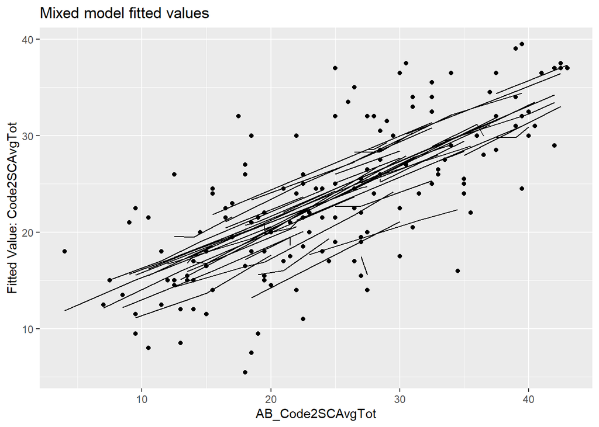

```
## [1] "Model 2a: Code2SCAvgTot~age+MRNVIQ+MRVIQ"
```

```
##      Variable Estimate          CI_95 DF p_value
## 1 (Intercept)   45.860 (38.07, 53.65) 49  <0.001
## 2         age   -0.320 (-0.46, -0.18) 49  <0.001
## 3      MRNVIQ   -0.055  (-0.13, 0.02) 49   0.166
## 4       MRVIQ   -0.121 (-0.18, -0.06) 49  <0.001
```

```
## [1] "Model 2b: AB_Code2SCAvgTot~age+MRNVIQ+MRVIQ"
```

```
##      Variable Estimate          CI_95 DF p_value
## 1 (Intercept)   49.539  (40.98, 58.1) 49  <0.001
## 2         age   -0.291 (-0.44, -0.14) 49  <0.001
## 3      MRNVIQ   -0.025  (-0.11, 0.06) 49   0.561
## 4       MRVIQ   -0.202 (-0.27, -0.14) 49  <0.001
```

# Repetitive Behaviors

```
## [1] "Model 1: Code2RRBAvgTot~AB_Code2RRBAvgTot+age+AB_Code2RRBAvgTot*age"
```

```
##                Variable Estimate         CI_95 DF p_value
## 1           (Intercept)    3.522 (-0.87, 7.91) 93   0.114
## 2     AB_Code2RRBAvgTot    0.336 (-0.11, 0.79) 93   0.141
## 3                   age   -0.013 (-0.17, 0.15) 93   0.873
## 4 AB_Code2RRBAvgTot:age    0.000 (-0.02, 0.02) 93   0.991
```

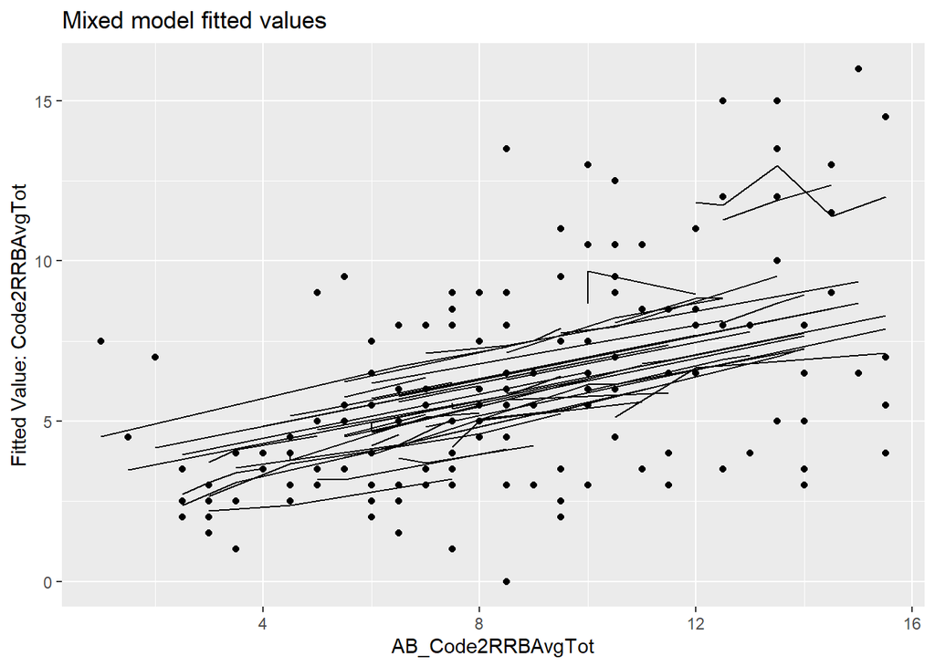

```
## [1] "Model 2a: Code2RRBAvgTot~age+MRNVIQ+MRVIQ"
```

```
##      Variable Estimate          CI_95 DF p_value
## 1 (Intercept)   13.006  (8.84, 17.17) 49  <0.001
## 2         age   -0.060  (-0.15, 0.03) 49   0.182
## 3      MRNVIQ   -0.051 (-0.09, -0.01) 49   0.013
## 4       MRVIQ   -0.016  (-0.04, 0.01) 49   0.271
```

```
## [1] "Model 2b: AB_Code2RRBAvgTot~age+MRNVIQ+MRVIQ"
```

[output not shown]

# Latent Variable Modeling

We first consider growth mixture modeling using the SC and RRB BOSCC scores for both types of BOSCC tests. That is, we consider 4 models, one for each outcome, with the following covariates: age, Verbal IQ and Non-Verbal IQ. We see look at the class memberships for the infants in each of the 4 models.

## Missingness

We can see that there is a large amount of observations with missing IQ values at certain time points (and thus are removed from any longitudinal analysis, subjects kept, just obs. removed). While mixed model methods will still result in unbiased estimates and standard errors (assuming missing at random), power is severely compromised. Under this MAR assumption, we can improve power while maintaining the unbiased property by using multiple imputation.

Below we print counts of missingness and implement the imputation method. First, we do single subject-specific imputation using mixed modeling with IQ/Non-verbal IQ as the outcome and time, gender as fixed effects. Random effects are a random intercept and random slope for time to represent subject-specific trends in IQ. We then impute the missing value based on the subject’s trend (fixed+random effects) at the given time point of missingness. **We will move to a similar multiple imputation implementation**

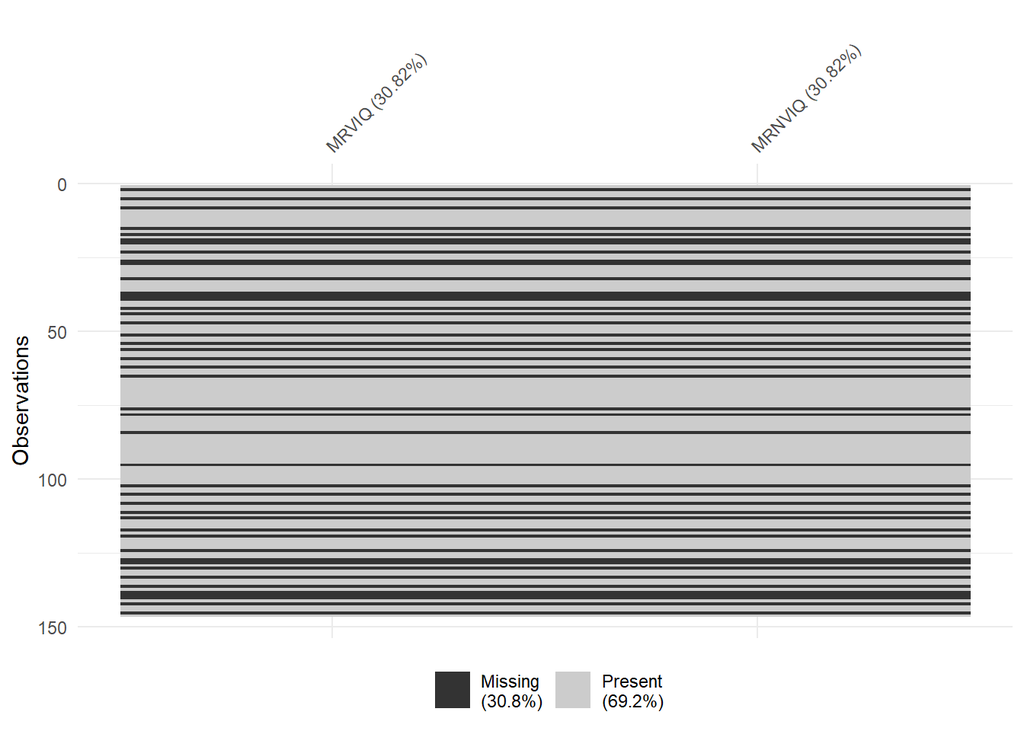

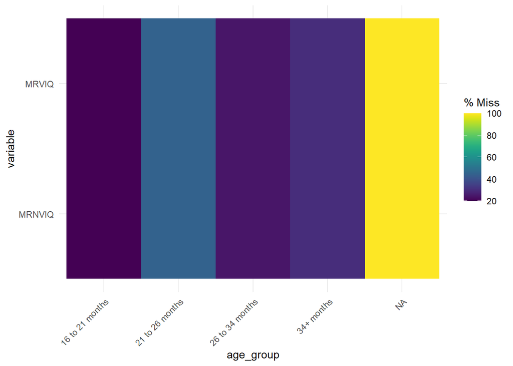

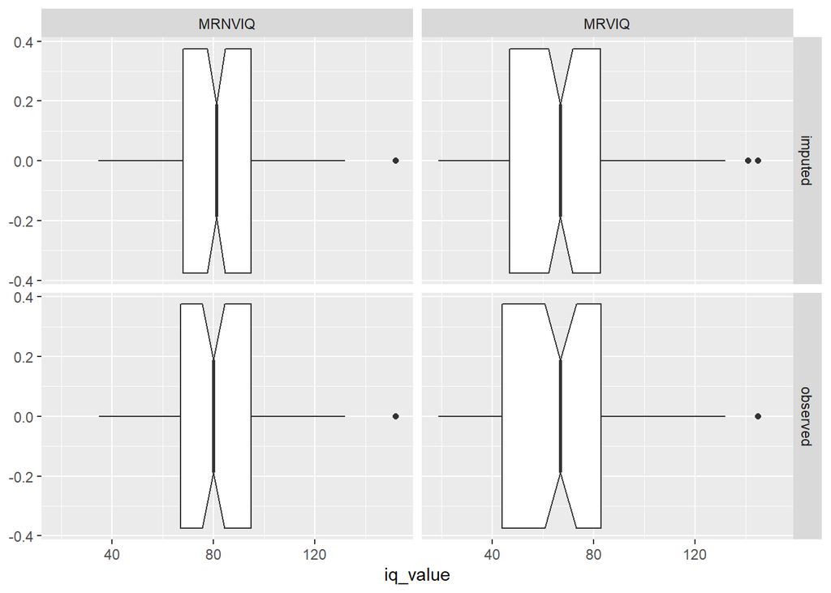

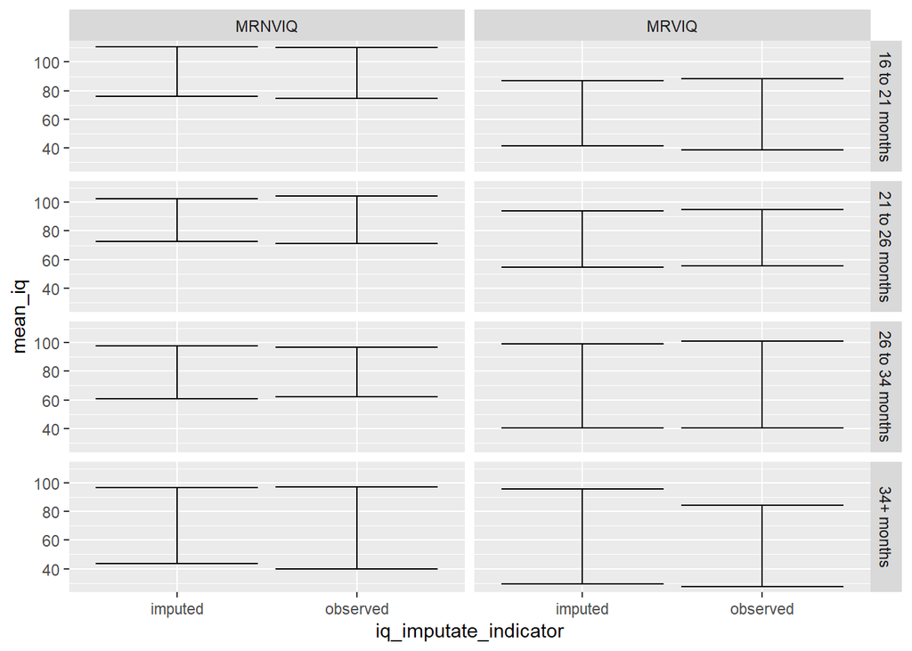

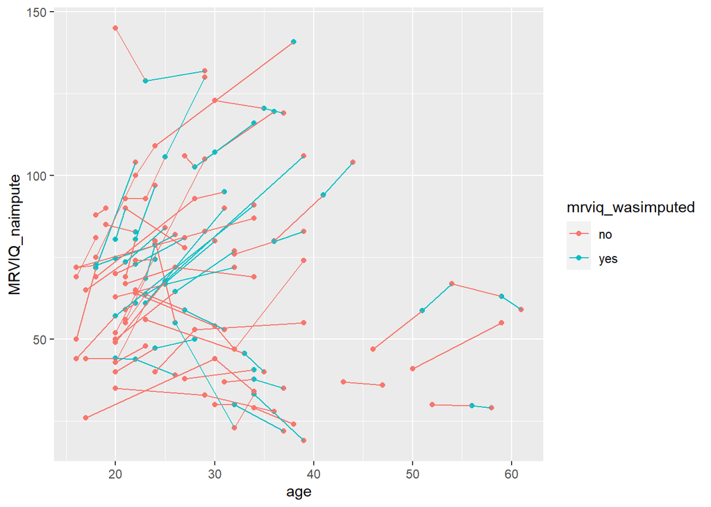

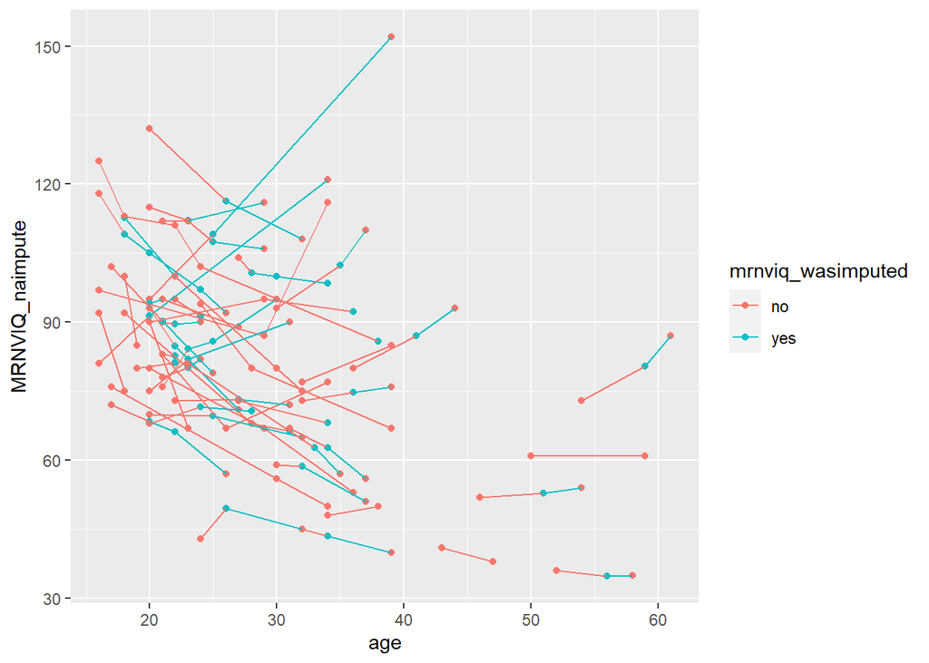

## Modeling

We consider 4 models, one for each outcome, with the following covariates: age, Verbal IQ and Non-Verbal IQ. We see look at the class memberships for the infants in each of the 4 models. We consider two types of modeling for each; latent class growth models (LCGA) and growth mixture models (GMM). Both are extensions of mixed models, but the addition of unobserved/latent groups which are predicted by the model. That is, along with fixed and random effects, we include class probability modeling which can be influenced by covariates as well as class-specific fixed effects. The difference between the two is GMM allows the variance/covariance of the random effects to differ between the groups while LCGA forces them to be the same (and thus is computationally easier/has less parameters to estimate). We use BIC to determine the “best fitting” model for each outcome, and consider 1, 2, and 3 latent groups (as separate models, 1 group is considered “baseline” model for comparison with respect to model fit). Maximum likelihood through the expectation maximization (EM) algorithm is done for the estimation. We use the dataset with imputed IQ values. Note ID must be numeric for function to work (numeric IDs created in code).

## K-Means Analysis

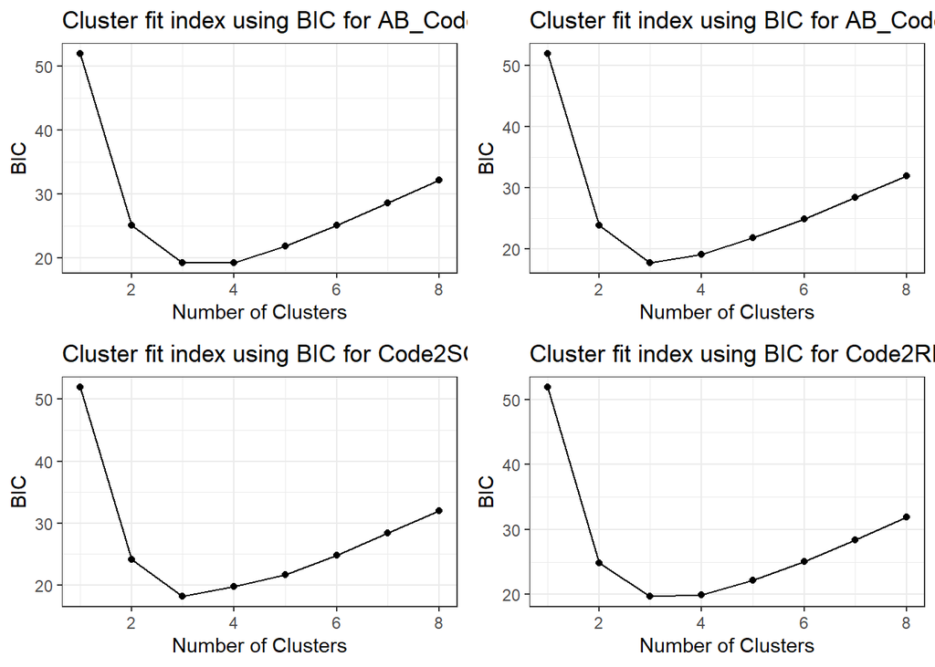

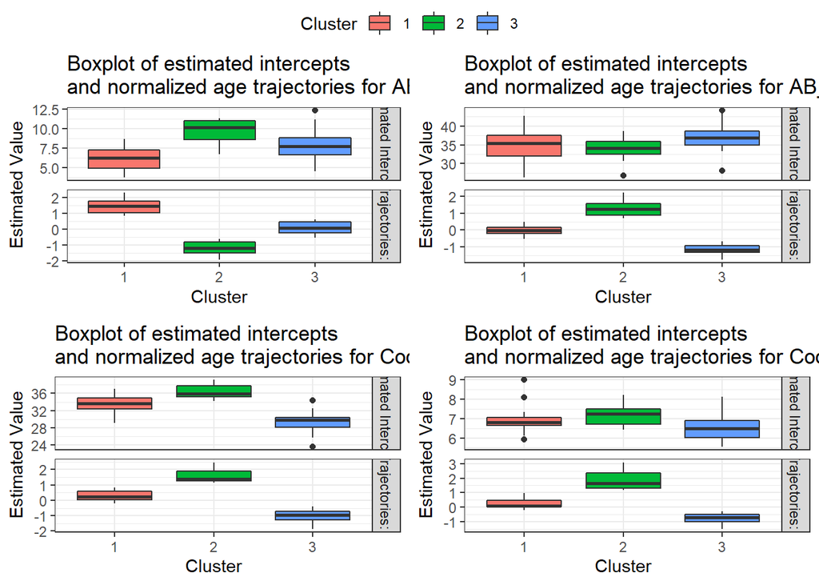

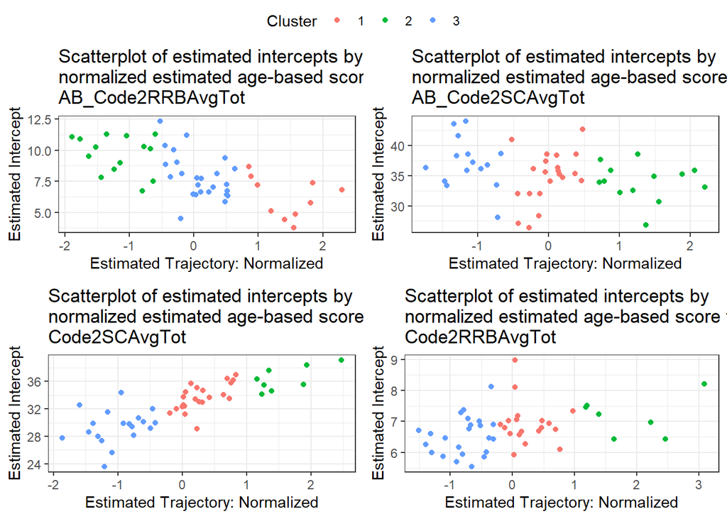

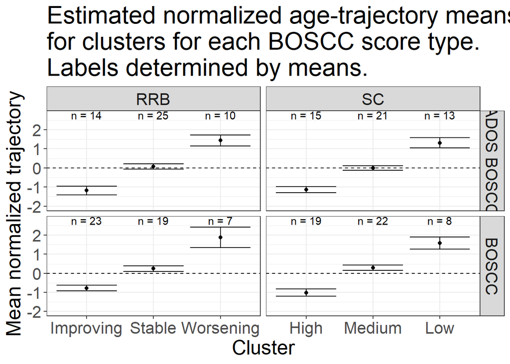

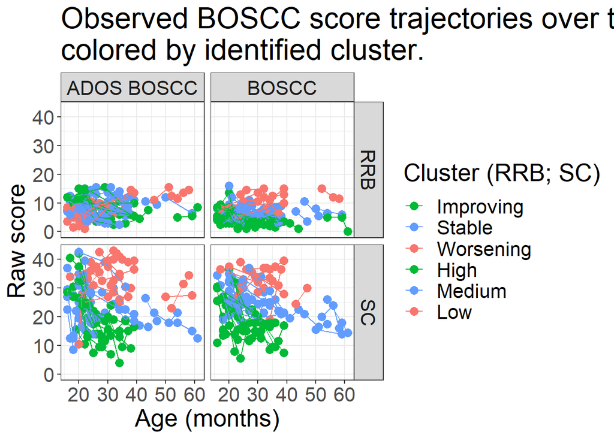

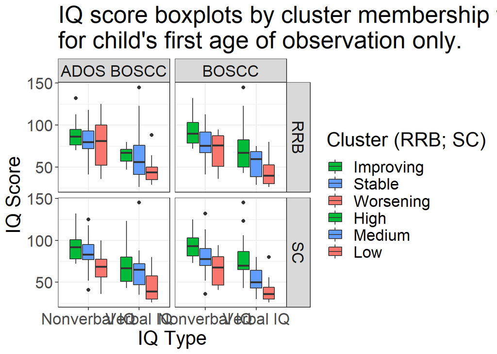

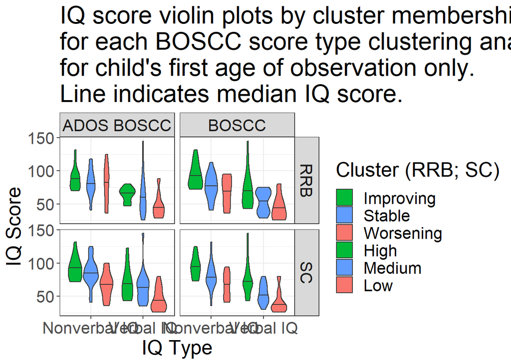

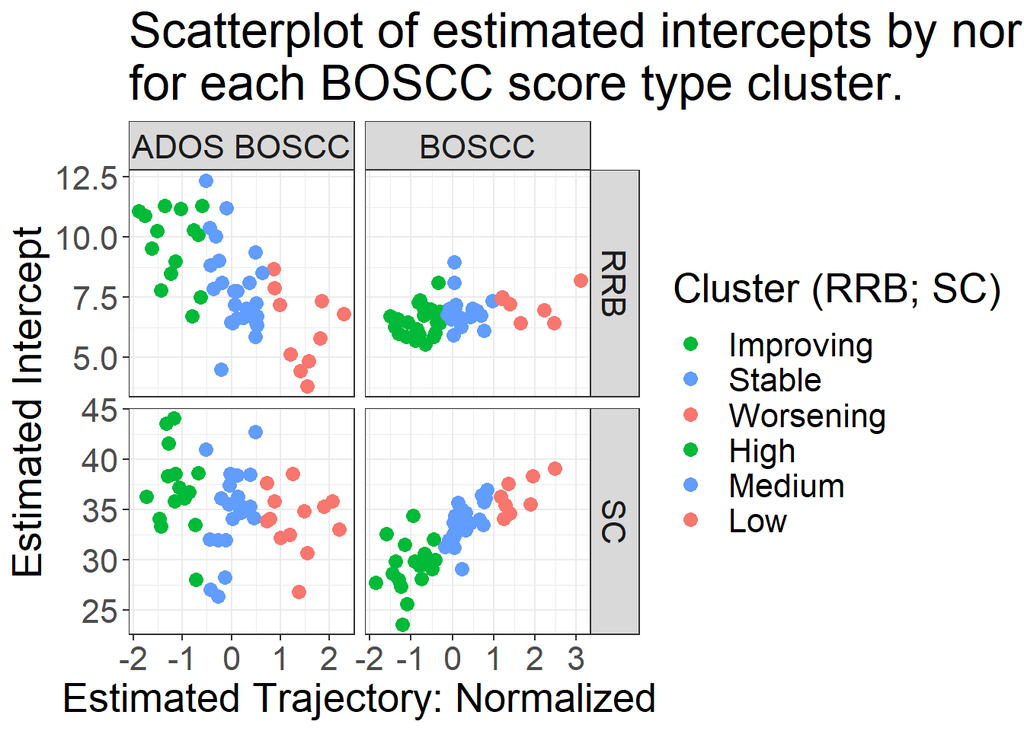

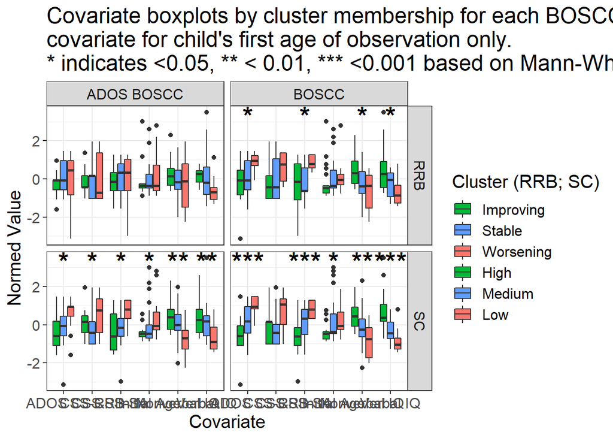

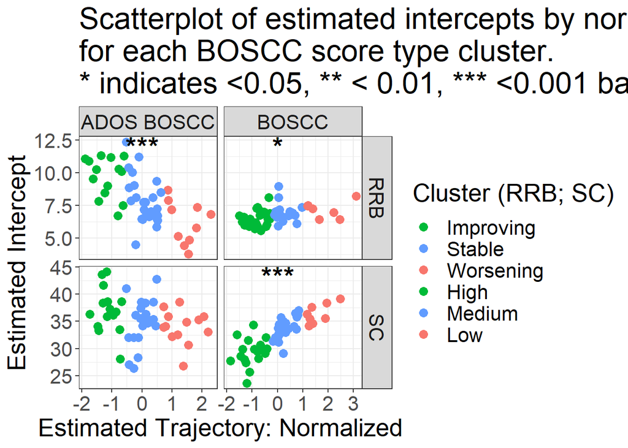

### Examine clusters

- **RRB**:

  |  | Improving | Stable | Worsening |
  | --- | --- | --- | --- |
  | **Improving** | 7 (0.14) | 6 (0.12) | 1 (0.02) |
  | **Stable** | 13 (0.27) | 8 (0.16) | 4 (0.08) |
  | **Worsening** | 3 (0.06) | 5 (0.1) | 2 (0.04) |

- **SC**:

  |  | High | Medium | Low |
  | --- | --- | --- | --- |
  | **High** | 10 (0.2) | 5 (0.1) | 0 (0) |
  | **Medium** | 9 (0.18) | 10 (0.2) | 2 (0.04) |
  | **Low** | 0 (0) | 7 (0.14) | 6 (0.12) |

### Cutoff scores for clusters

| boscc_type | boscc_subscale | cluster_labels | median_og_traj | iqr |
| --- | --- | --- | --- | --- |
| ADOS BOSCC | RRB | Improving | -0.156 | 0.164 |
|  |  | Stable | 0.131 | 0.157 |
|  |  | Worsening | 0.454 | 0.162 |
|  | SC | High | -3.919 | 0.567 |
|  |  | Medium | -2.347 | 0.511 |
|  |  | Low | -0.564 | 0.941 |
| BOSCC | RRB | Improving | -0.379 | 0.158 |
|  |  | Stable | -0.124 | 0.138 |
|  |  | Worsening | 0.353 | 0.326 |
|  | SC | High | -2.465 | 0.318 |
|  |  | Medium | -1.800 | 0.311 |
|  |  | Low | -1.155 | 0.357 |

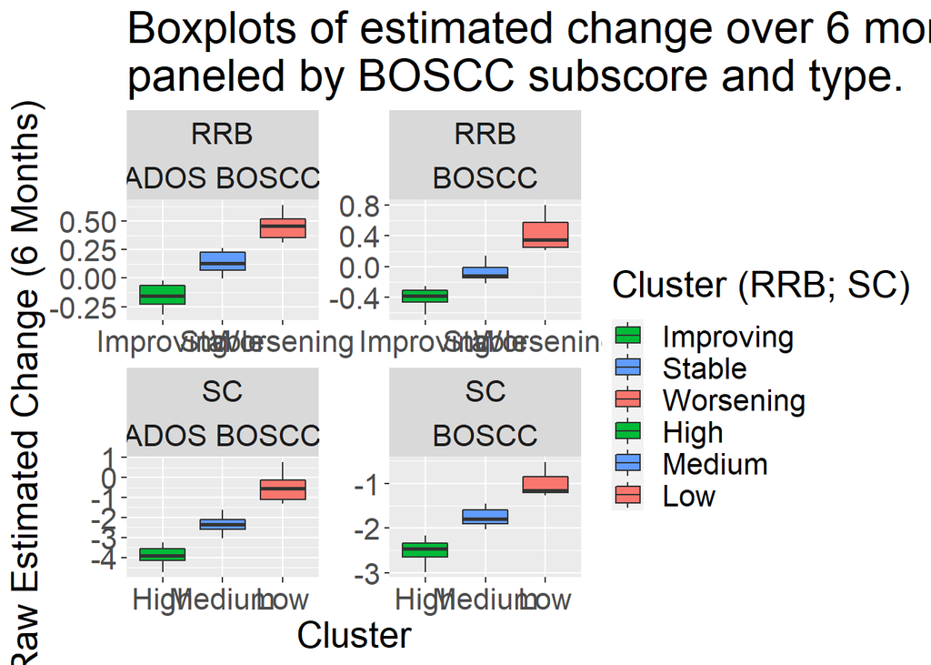